# DS Final Project

**Introduction** The key question I am trying to explore is: Can a model decide if a book is a “good” book or not from some of its attributes.

My hypothesis: Yes. A model can predict with reasonable accuracy if a book is “good” or not based on its features

**Import useful libraries**

```r
library(tidyverse) # for general graphing
library(caret) # confusion matrix
library(caTools) # sample splitting
library(dplyr) # for reformatting a column
library(corrplot) # for making correlation matrix
```

**Cleaning data**

Reading in Data: Here is the dataset I used

```r
# read in the data
books_unmod <- read.csv("C:/Users/jli/OneDrive - Eastside Preparatory School/Data Science/Regressions/Data/best_books.csv")

# check data
glimpse(books_unmod)
```

```
Rows: 52,478
Columns: 25
$ bookId           <chr> "2767052-the-hunger-games", "2.Harry_Potter_and_the_…
$ title            <chr> "The Hunger Games", "Harry Potter and the Order of t…
$ series           <chr> "The Hunger Games #1", "Harry Potter #5", "To Kill a…
$ author           <chr> "Suzanne Collins", "J.K. Rowling, Mary GrandPré (Ill…
$ rating           <dbl> 4.33, 4.50, 4.28, 4.26, 3.60, 4.37, 3.95, 4.26, 4.60…
$ description      <chr> "WINNING MEANS FAME AND FORTUNE.LOSING MEANS CERTAIN…
$ language         <chr> "English", "English", "English", "English", "English…
$ isbn             <chr> "9.78044E+12", "9.78044E+12", "1E+13", "1E+13", "9.7…
$ genres           <chr> "['Young Adult', 'Fiction', 'Dystopia', 'Fantasy', '…
$ characters       <chr> "['Katniss Everdeen', 'Peeta Mellark', 'Cato (Hunger…
$ bookFormat       <chr> "Hardcover", "Paperback", "Paperback", "Paperback", …
$ edition          <chr> "First Edition", "US Edition", "", "Modern Library C…
$ pages            <chr> "374", "870", "324", "279", "501", "552", "141", "76…
$ publisher        <chr> "Scholastic Press", "Scholastic Inc.", "Harper Peren…
$ publishDate      <chr> "9/14/2008", "9/28/2004", "5/23/2006", "10/10/2000",…
$ firstPublishDate <chr> "", "6/21/2003", "7/11/1960", "1/28/2013", "10/5/200…
$ awards           <chr> "['Locus Award Nominee for Best Young Adult Book (20…
$ numRatings       <int> 6376780, 2507623, 4501075, 2998241, 4964519, 1834276…
$ ratingsByStars   <chr> "['3444695', '1921313', '745221', '171994', '93557']…
$ likedPercent     <int> 96, 98, 95, 94, 78, 96, 91, 96, 98, 94, 93, 94, 94, …
$ setting          <chr> "['District 12, Panem', 'Capitol, Panem', 'Panem (Un…
$ coverImg         <chr> "https://i.gr-assets.com/images/S/compressed.photo.g…
$ bbeScore         <int> 2993816, 2632233, 2269402, 1983116, 1459448, 1372809…
$ bbeVotes         <int> 30516, 26923, 23328, 20452, 14874, 14168, 13264, 129…
$ price            <chr> "5.09", "7.38", "", "", "2.1", "3.8", "4.42", "", "2…
```

```r
# Data: https://zenodo.org/record/4265096#.ZAEGqXbMI2w
```

I chose this dataset because: - It has many things to pick and choose from - I can practice cleaning data and making it work for my project

Getting rid of irrelevant columns

```r
# remove selected columns
books <- books_unmod %>% select(-c(bookId, description, isbn, characters, bookFormat, edition, setting, coverImg, bbeVotes, publishDate, title, author, publisher, genres, ratingsByStars, likedPercent, bbeScore))

# check data
glimpse(books)
```

```
Rows: 52,478
Columns: 8
$ series           <chr> "The Hunger Games #1", "Harry Potter #5", "To Kill a…
$ rating           <dbl> 4.33, 4.50, 4.28, 4.26, 3.60, 4.37, 3.95, 4.26, 4.60…
$ language         <chr> "English", "English", "English", "English", "English…
$ pages            <chr> "374", "870", "324", "279", "501", "552", "141", "76…
$ firstPublishDate <chr> "", "6/21/2003", "7/11/1960", "1/28/2013", "10/5/200…
$ awards           <chr> "['Locus Award Nominee for Best Young Adult Book (20…
$ numRatings       <int> 6376780, 2507623, 4501075, 2998241, 4964519, 1834276…
$ price            <chr> "5.09", "7.38", "", "", "2.1", "3.8", "4.42", "", "2…
```

Creating binary columns

```r
# determine if this book belongs in a series
books$seriesBinary<-ifelse(books$series == "", 0, 1)

# determine if this book is written in English or not
books$langBinary<-ifelse(books$language == "English", 1, 0)

# determine if this book has won an award
books$binaryAwards<-ifelse(books$awards == "[]", 0, 1)

# determine if this book is a good book or not
# the threshold I use is a rating of 4 (i.e. "good" books have >4 ratings)
books$binary_rating<-factor(ifelse(books$rating<=4,0,1))

# get rid of columns I just fixed
books <- books %>% select(-c(series, language, awards))

# check on data
glimpse(books)
```

```
Rows: 52,478
Columns: 9
$ rating           <dbl> 4.33, 4.50, 4.28, 4.26, 3.60, 4.37, 3.95, 4.26, 4.60…
$ pages            <chr> "374", "870", "324", "279", "501", "552", "141", "76…
$ firstPublishDate <chr> "", "6/21/2003", "7/11/1960", "1/28/2013", "10/5/200…
$ numRatings       <int> 6376780, 2507623, 4501075, 2998241, 4964519, 1834276…
$ price            <chr> "5.09", "7.38", "", "", "2.1", "3.8", "4.42", "", "2…
$ seriesBinary     <dbl> 1, 1, 1, 0, 1, 0, 0, 1, 1, 0, 0, 1, 0, 0, 1, 0, 0, 1…
$ langBinary       <dbl> 1, 1, 1, 1, 1, 1, 1, 1, 1, 1, 1, 1, 1, 1, 1, 1, 1, 1…
$ binaryAwards     <dbl> 1, 1, 1, 0, 1, 1, 1, 0, 0, 1, 1, 0, 0, 0, 1, 0, 0, 0…
$ binary_rating    <fct> 1, 1, 1, 1, 0, 1, 0, 1, 1, 1, 1, 1, 1, 0, 0, 1, 1, 1…
```

Get the first publish year of a book

```r
# remove the month and data of the date. Original format: x/x/xxxx
books$firstPublishDate <- str_sub(books$firstPublishDate, -4, -1)

# check on data
glimpse(books)
```

```
Rows: 52,478
Columns: 9
$ rating           <dbl> 4.33, 4.50, 4.28, 4.26, 3.60, 4.37, 3.95, 4.26, 4.60…
$ pages            <chr> "374", "870", "324", "279", "501", "552", "141", "76…
$ firstPublishDate <chr> "", "2003", "1960", "2013", "2005", "2005", "1945", …
$ numRatings       <int> 6376780, 2507623, 4501075, 2998241, 4964519, 1834276…
$ price            <chr> "5.09", "7.38", "", "", "2.1", "3.8", "4.42", "", "2…
$ seriesBinary     <dbl> 1, 1, 1, 0, 1, 0, 0, 1, 1, 0, 0, 1, 0, 0, 1, 0, 0, 1…
$ langBinary       <dbl> 1, 1, 1, 1, 1, 1, 1, 1, 1, 1, 1, 1, 1, 1, 1, 1, 1, 1…
$ binaryAwards     <dbl> 1, 1, 1, 0, 1, 1, 1, 0, 0, 1, 1, 0, 0, 0, 1, 0, 0, 0…
$ binary_rating    <fct> 1, 1, 1, 1, 0, 1, 0, 1, 1, 1, 1, 1, 1, 0, 0, 1, 1, 1…
```

```r
# Source: get last characters in a string: https://statisticsglobe.com/r-extract-first-or-last-n-characters-from-string
```

Check for NA/white spaces

```r
# checking for white spaces
colSums(books == "")
```

```
          rating            pages firstPublishDate       numRatings
               0             2347            21326                0
           price     seriesBinary       langBinary     binaryAwards
           14365                0                0                0
   binary_rating
               0
```

```r
books <- books  %>% filter(pages != "")
books <- books  %>% filter(price != "")
books <- books  %>% filter(firstPublishDate != "")

# check for NA
colSums(is.na(books))
```

```
          rating            pages firstPublishDate       numRatings
               0                0                0                0
           price     seriesBinary       langBinary     binaryAwards
               0                0                0                0
   binary_rating
               0
```

```r
books <- na.omit(books)

# check if there are white spaces or NAs left
colSums(books == "")
```

```
          rating            pages firstPublishDate       numRatings
               0                0                0                0
           price     seriesBinary       langBinary     binaryAwards
               0                0                0                0
   binary_rating
               0
```

```r
colSums(is.na(books))
```

```
          rating            pages firstPublishDate       numRatings
               0                0                0                0
           price     seriesBinary       langBinary     binaryAwards
               0                0                0                0
   binary_rating
               0
```

Converting certain character columns to numeric

```r
# select the columns with character columns
i <- c(2, 3, 5)

# convert these columns to be numeric
books[ , i] <- apply(books[ , i], 2, function(x) as.numeric(as.character(x)))
colSums(is.na(books))
```

```
          rating            pages firstPublishDate       numRatings
               0                8              125                0
           price     seriesBinary       langBinary     binaryAwards
               9                0                0                0
   binary_rating
               0
```

```r
books <- na.omit(books)

# check if character columns are gone
glimpse(books)
```

```
Rows: 24,632
Columns: 9
$ rating           <dbl> 4.50, 3.60, 4.37, 3.95, 4.60, 4.30, 4.37, 3.86, 4.12…
$ pages            <dbl> 870, 501, 552, 141, 1728, 1037, 64, 464, 503, 239, 5…
$ firstPublishDate <dbl> 2003, 2005, 2005, 1945, 1955, 1936, 1964, 1947, 1997…
$ numRatings       <int> 2507623, 4964519, 1834276, 2740713, 110146, 1074620,…
$ price            <dbl> 7.38, 2.10, 3.80, 4.42, 21.15, 5.58, 4.87, 2.73, 2.7…
$ seriesBinary     <dbl> 1, 1, 0, 0, 1, 0, 0, 0, 0, 1, 0, 1, 0, 0, 0, 0, 1, 1…
$ langBinary       <dbl> 1, 1, 1, 1, 1, 1, 1, 1, 1, 1, 1, 1, 1, 1, 1, 1, 1, 1…
$ binaryAwards     <dbl> 1, 1, 1, 1, 0, 1, 0, 0, 0, 0, 0, 1, 0, 0, 1, 0, 1, 0…
$ binary_rating    <fct> 1, 0, 1, 0, 1, 1, 1, 0, 1, 1, 1, 1, 0, 0, 0, 1, 1, 1…
```

```r
# Source changing char columns to numeric: https://statisticsglobe.com/convert-data-frame-column-to-numeric-in-r
```

**Use correlation to determine helpful features** I can’t use the binary_rating column to test correlations because only numerical values can generate this graph. So instead, I use rating to see which features have strongest correlations

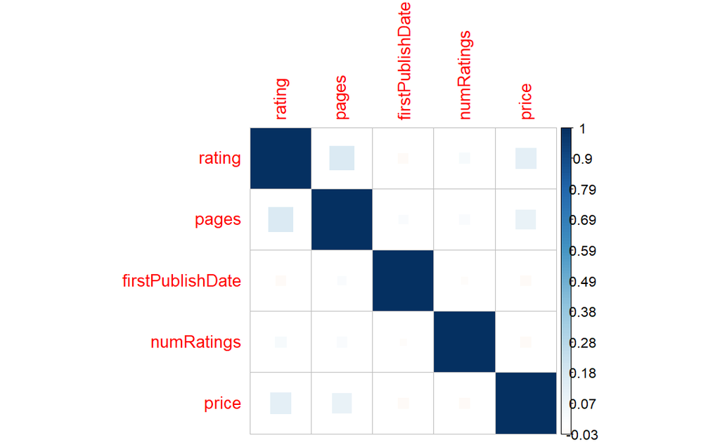

```r
# generate a correlation matrix
books_cor = subset(books, select = -c(seriesBinary, langBinary, binaryAwards, binary_rating))
books_cor <- as.data.frame(books_cor)
M <- cor(books_cor)
corrplot(M, is.corr = FALSE, method = "square")
```

```r
# Source: building correlation matrix https://www.geeksforgeeks.org/correlation-matrix-in-r-programming/
```

**Visualizing Correlations** Correlation between rating and pages

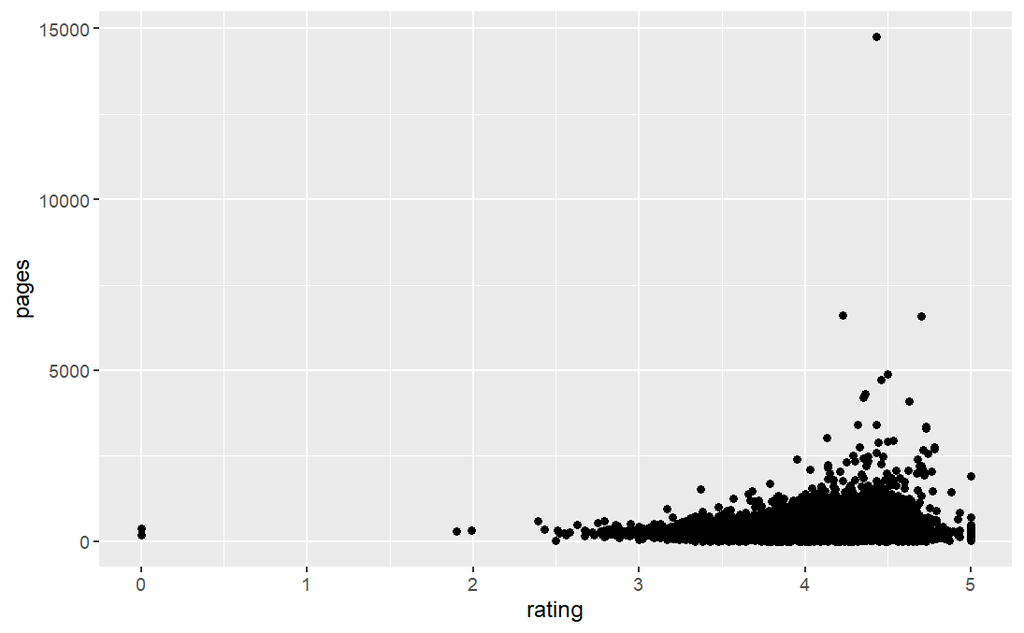

```r
ggplot(books, aes(x = rating, y = pages)) +
    geom_point()
```

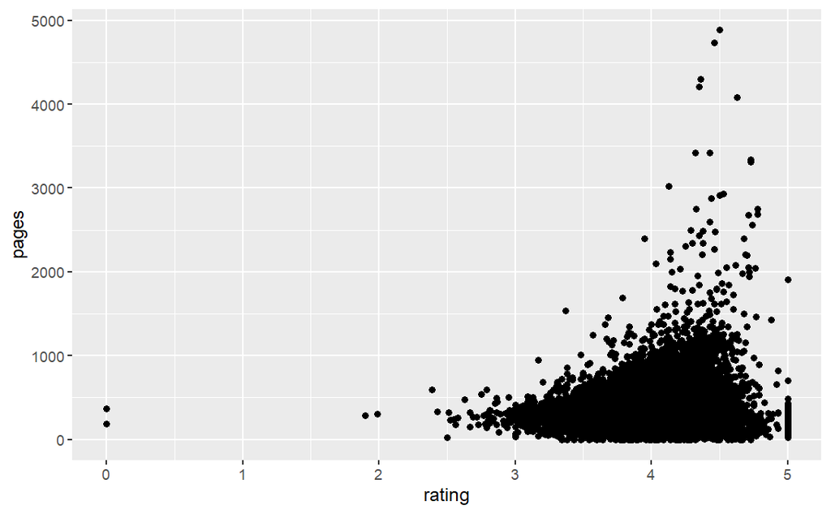

```r
# zooming in
potential_outliers1 <- books |>
  filter(pages < 5000)

ggplot(potential_outliers1, aes(x = rating, y = pages)) +
    geom_point()
```

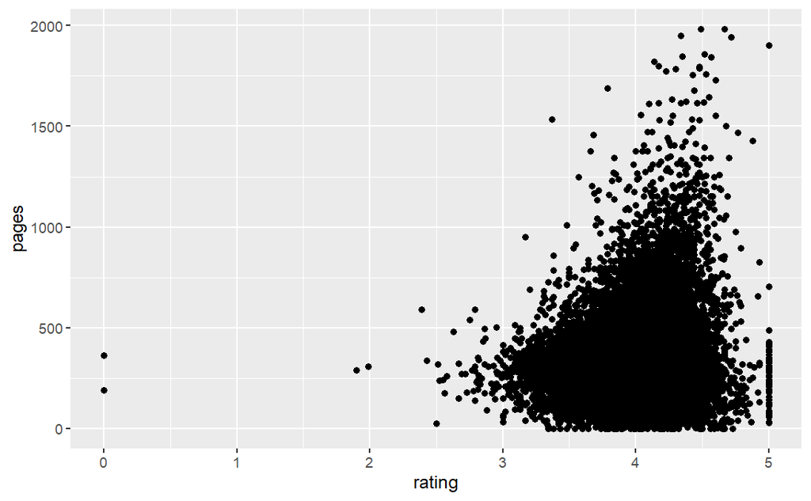

```r
# zooming in some more
potential_outliers2 <- books |>
  filter(pages < 2000)

ggplot(potential_outliers2, aes(x = rating, y = pages)) +
    geom_point()
```

Correlation between rating and price

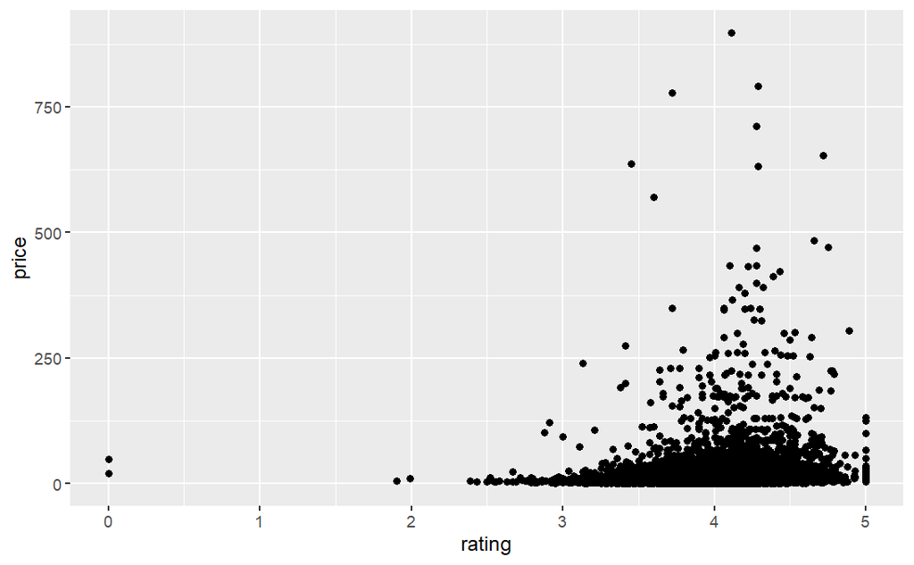

```r
ggplot(books, aes(x = rating, y = price)) +
    geom_point()
```

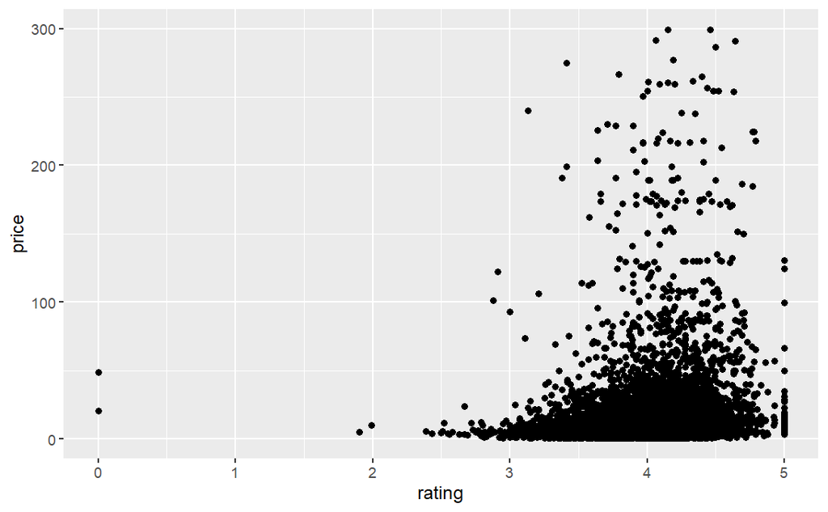

```r
# zooming in
potential_outliers3 <- books |>
  filter(price < 300)

ggplot(potential_outliers3, aes(x = rating, y = price)) +
    geom_point()
```

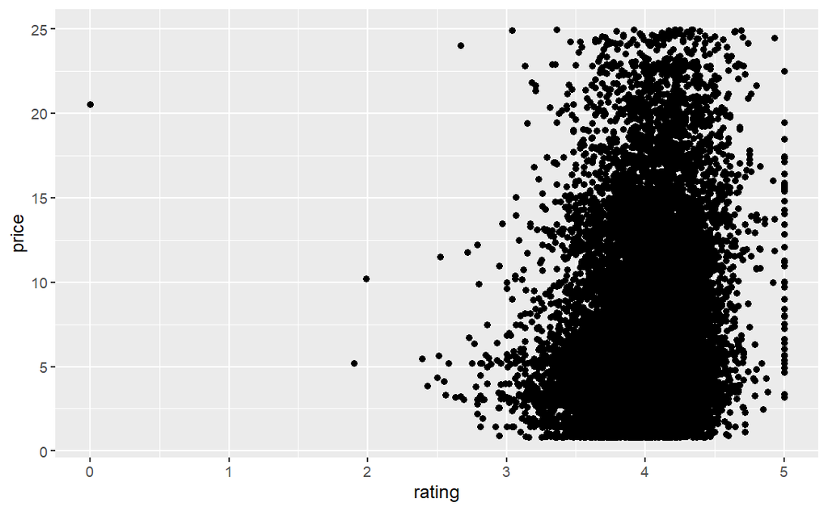

```r
# zooming in some more
potential_outliers4 <- books |>
  filter(price < 25)

ggplot(potential_outliers4, aes(x = rating, y = price)) +
    geom_point()
```

Conclusions: Outliers could be skewing with the correlations, but getting rid of outliers might be tricky since this is still important information about books. Also, the correlations are not that promising.

**Modeling Data**

```r
# split the data into train and test, 70% to train this time
set.seed(142)
sampleSplit <- sample.split(Y=books$binary_rating, SplitRatio=0.7)
train <- subset(x=books, sampleSplit==TRUE)
test <- subset(x=books, sampleSplit==FALSE)

# model based on the train set
model <- glm(binary_rating ~ binaryAwards + pages + price + numRatings + langBinary + seriesBinary + firstPublishDate, family = binomial(link='logit'), data=train)

# make another model with the best predictor features
model_curated <- glm(binary_rating ~ pages + seriesBinary + firstPublishDate + binaryAwards, family = binomial(link='logit'), data=train)

# check how the model is doing
summary(model)
```

```
Call:
glm(formula = binary_rating ~ binaryAwards + pages + price +
    numRatings + langBinary + seriesBinary + firstPublishDate,
    family = binomial(link = "logit"), data = train)

Deviance Residuals:
    Min       1Q   Median       3Q      Max
-4.4826  -1.0961  -0.9016   1.1708   1.6127

Coefficients:
                   Estimate Std. Error z value Pr(>|z|)
(Intercept)       5.214e+00  1.402e+00   3.719   0.0002 ***
binaryAwards     -1.770e-01  3.720e-02  -4.758 1.95e-06 ***
pages             1.441e-03  8.792e-05  16.394  < 2e-16 ***
price             1.363e-02  1.348e-03  10.105  < 2e-16 ***
numRatings        3.281e-07  1.743e-07   1.883   0.0597 .
langBinary        1.261e-01  5.160e-02   2.445   0.0145 *
seriesBinary      4.845e-01  3.209e-02  15.097  < 2e-16 ***
firstPublishDate -3.090e-03  7.044e-04  -4.387 1.15e-05 ***
---
Signif. codes:  0 ‘***’ 0.001 ‘**’ 0.01 ‘*’ 0.05 ‘.’ 0.1 ‘ ’ 1

(Dispersion parameter for binomial family taken to be 1)

    Null deviance: 23886  on 17241  degrees of freedom
Residual deviance: 23090  on 17234  degrees of freedom
AIC: 23106

Number of Fisher Scoring iterations: 5
```

```r
summary(model_curated)
```

```
Call:
glm(formula = binary_rating ~ pages + seriesBinary + firstPublishDate +
    binaryAwards, family = binomial(link = "logit"), data = train)

Deviance Residuals:
    Min       1Q   Median       3Q      Max
-4.1326  -1.1065  -0.9201   1.1740   1.5940

Coefficients:
                   Estimate Std. Error z value Pr(>|z|)
(Intercept)       6.251e+00  1.400e+00   4.464 8.04e-06 ***
pages             1.465e-03  8.652e-05  16.931  < 2e-16 ***
seriesBinary      4.762e-01  3.182e-02  14.965  < 2e-16 ***
firstPublishDate -3.495e-03  7.040e-04  -4.964 6.89e-07 ***
binaryAwards     -1.841e-01  3.658e-02  -5.033 4.84e-07 ***
---
Signif. codes:  0 ‘***’ 0.001 ‘**’ 0.01 ‘*’ 0.05 ‘.’ 0.1 ‘ ’ 1

(Dispersion parameter for binomial family taken to be 1)

    Null deviance: 23886  on 17241  degrees of freedom
Residual deviance: 23255  on 17237  degrees of freedom
AIC: 23265

Number of Fisher Scoring iterations: 4
```

Predictions

```r
# use predict on the test set to determine accuracy
results_curated<- predict(model_curated, newdata=test, type='response')
results_curated <- ifelse(results_curated > 0.5,1,0)

# Confusion matrix - true and false positives/negatives
confusionMatrix(factor(results_curated), factor(test$binary_rating))
```

```
Confusion Matrix and Statistics

          Reference
Prediction    0    1
         0 2479 1859
         1 1331 1721

               Accuracy : 0.5683
                 95% CI : (0.557, 0.5797)
    No Information Rate : 0.5156
    P-Value [Acc > NIR] : < 2.2e-16

                  Kappa : 0.132

 Mcnemar's Test P-Value : < 2.2e-16

            Sensitivity : 0.6507
            Specificity : 0.4807
         Pos Pred Value : 0.5715
         Neg Pred Value : 0.5639
             Prevalence : 0.5156
         Detection Rate : 0.3355
   Detection Prevalence : 0.5870
      Balanced Accuracy : 0.5657

       'Positive' Class : 0
```

This is definitely not a great answer to my question because a lot of crucial information about the book such as character, setting, and author are ignored. Also a threshold of 4 is not great because it makes some features like awards not as important

If I have more time: - Find a dataset with a better distribution of ratings - I would try to incorporate the nonnumerical features (somehow) to get more reliable results

**Quiz Question** What is one reason I removed columns (any column)?